# Correlated evolution of chlorophyllous-spored ferns, mycorrhizae, and habits

Author

Daniela Mellado-Mansilla

## Libraries

```r
pacman::p_load(ape, diversitree, phytools, geiger, readxl, picante)
```

## MuSSE (Multi-State Speciation and Extinction) analysis

This code was used to perform a MuSSE analysis for the publication “[*The relationship between chlorophyllous spores and mycorrhizal associations in ferns: evidence from an evolutionary approach*](https://doi.org/10.1002/ajb2.16094)”. We used this analyses to obtain the transition rates between states as showed in the paper:

Fig. 3 of Mellado-Mansilla et al. 2022

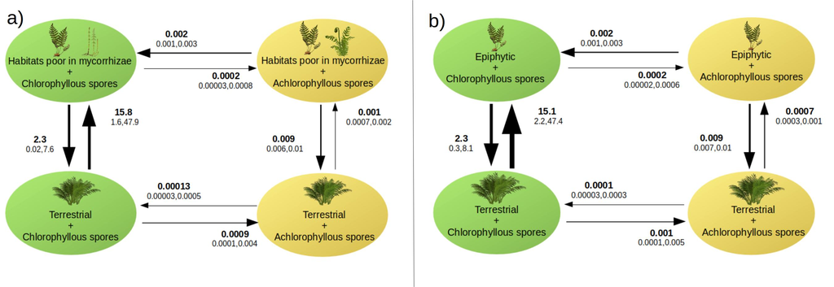

Here, I provide an example with the habit (epiphytic or terrestrial) vs. the spore type (chlorophyllous, non-chlorophyllous). You can find other codes related with this publication [here](https://datadryad.org/stash/dataset/doi:10.5061/dryad.bnzs7h4cr).

### Data

Two binary traits: spore type (chlorophyllous 1, non-chlorophyllous 0) and ‘habit d’ (epiphyte 1, terrestrial 0)

```r
musse_epiter <- read_excel("traits_final.xlsx") %>%
  as.data.frame()%>%
  select.list(., 1,2,6)

row.names(musse_epiter) <- musse_epiter$Species

musse_epiter <- na.omit(musse_epiter)
```

### Phylogeny

Fern phylogeny first published by [Hernadez-Rojas et al. 2021](https://doi.org/10.21425/F5FBG50023)

```r
#Upload tree
tree<-read.tree("5Feb_dated_tree.tre",tree.names = NULL)

#prune tree
matchmuet<-match.phylo.data(tree,musse_epiter)
musse_epiter2<-matchmuet$data
treemuet<-matchmuet$phy
treeaultra2 <- force.ultrametric(treemuet)


# Prepare states for MuSSE
states <- paste0(musse_epiter2$spore_type,musse_epiter2$habit_d)
states <- as.factor(states)
states <- as.numeric(states)
names(states) <- musse_epiter2$Species
```

**Here is our fern phylogeny with the information on each trait studied:**

Fig.1 Mellado-Mansilla et al. 2022

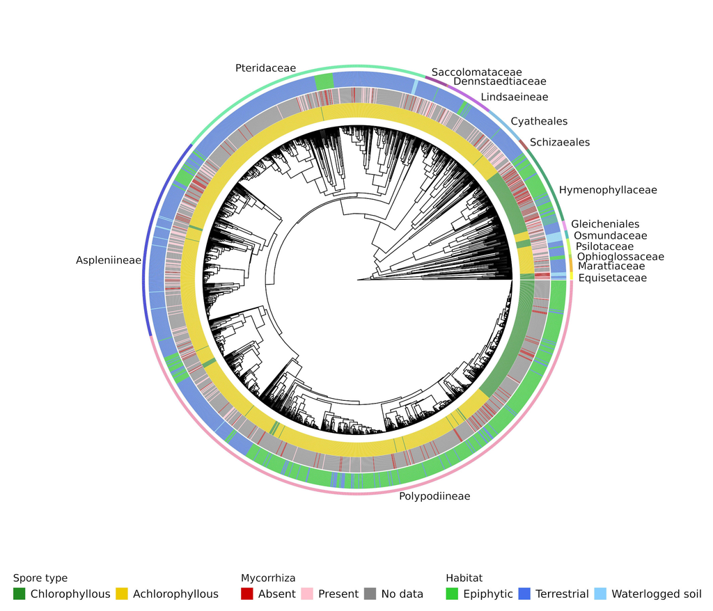

### Sampling factor

The analysis requires an estimated total number of the species with the character states to be analyzed. Here, I extrapolate the states according to the total species richness of extant ferns following [PPG1](https://doi.org/10.1111/jse.12229)

```r
#terrestrial achlorophyllous=7742
#epiphyte achlorophyllous=1339
#terrestrial chlorophyllous=231
#epiphyte chlorophyllous=1079

#species per state in my data
table(states)
#1   2   3   4
#951 433  46 296

#Proportional estimation
fet<-c(0.12,0.3,0.2,0.3)
```

## MuSSE

### Setting up the model parameters

```r
# musse model
liket <- make.musse(treeaultra2,states, k=4,sampling.f = fet)

# Constrain likelihood by setting extinction and transition rates
lik.et<-constrain(liket, mu2 ~ mu1, mu3 ~ mu1, mu4 ~ mu1,
                  q14 ~ 0, q41 ~ 0, q23 ~ 0, q32 ~ 0)

#Starting point
p<-starting.point.musse(treeaultra2,k=4)


#Fit the Model Using Maximum Likelihood Estimation (MLE)
fit.et <- find.mle(lik.et, p[argnames(lik.et)],method = "optim", control=list(optim.method="BFGS"))
```

### Set priors

```r
# Extract parameters to use the highest rate of ML as prior
fit.et$par.full
```

```
#> 0.2624152*2
```

```r
#[1] 0.5248304

prioret <- make.prior.exponential(0.52)
```

### Preliminar MCMC

Run this MCMC with only 100 steps to get starting points for the “real” MCMC

```r
prelimet <- diversitree::mcmc(lik.et, fit.et$par, nsteps=100, prior=prioret, w=1, lower=0, print.every=0)
summary(prelimet)

coef(fit.et)
fit.et$par

#prelimet is used to get the W parameter
wet <- diff(sapply(prelimet[2:(ncol(prelimet)-1)], quantile, c(0.05, 0.95)))
wet
```

## Final Models

```r
#mcmc
sampleset1<- diversitree::mcmc(lik.et, fit.et$par, nsteps=10000, w=wet, lower=0, prior=prioret, print.every=100,
save.file="mcmc_chain_epiter1.csv", save.every=5)


sampleset2<- diversitree::mcmc(lik.et, fit.et$par, nsteps=10000, w=wet, lower=0, prior=prioret, print.every=100,     save.file="mcmc_chain_epiter2.csv", save.every=5)


sampleset3<- diversitree::mcmc(lik.et, fit.et$par, nsteps=10000, w=wet, lower=0, prior=prioret, print.every=100,
save.file="mcmc_chain_epiter3.csv", save.every=5)


sampleset4<- diversitree::mcmc(lik.et, fit.et$par, nsteps=10000, w=wet, lower=0, prior=prioret, print.every=100,     save.file="mcmc_chain_epiter4.csv", save.every=5)
```

### Check the MCMC chains

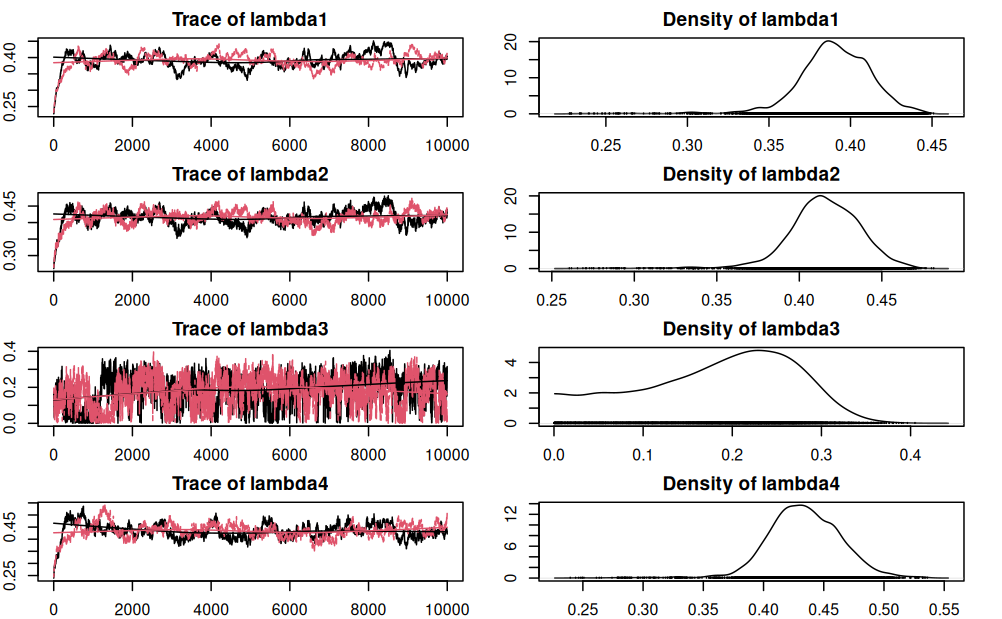

```r
# Analyze runs
library(coda)
runet1 <- coda::mcmc(sampleset1[,-1], start=1, thin=1)
runet2 <- coda::mcmc(sampleset2[,-1], start=1, thin=1)
runet3 <- coda::mcmc(sampleset3[,-1], start=1, thin=1)
runet4 <- coda::mcmc(sampleset4[,-1], start=1, thin=1)

runs_et <- coda::mcmc.list(runet1,runet2)

#plot diagnostics
par(mar=rep(2,4))
plot(runs_et)
effectiveSize(runs_et)
View(runs_et)
```

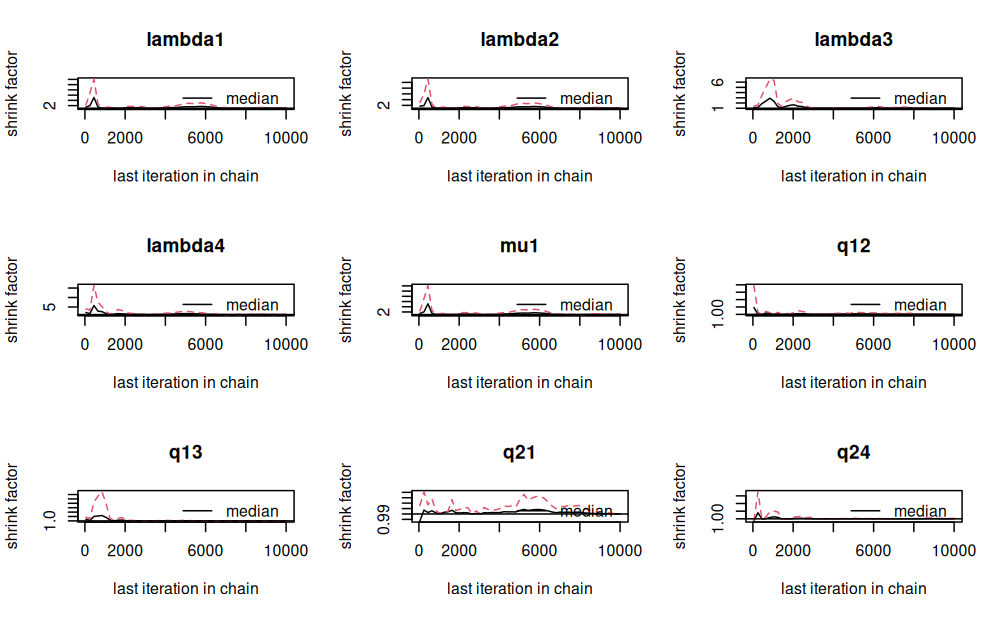

```r
#Gelman-Rubin Diagnostic Plot:
gelman.plot(runs_et)
gelman.diag(runs_et)
```

### Posterior probabilities

```r
####posterior probabilitiies
et1<-read.csv("mcmc_chain_epiter1___.csv")
et2<-read.csv("mcmc_chain_epiter2___.csv")
et3<-read.csv("mcmc_chain_epiter3___.csv")
et4<-read.csv("mcmc_chain_epiter4___.csv")

#burn in removing the first 1000 iterations from each MCMC chain
bi_et1<-subset(et1, i > 1000)
bi_et2<-subset(et2, i > 1000)
bi_et3<-subset(et3, i > 1000)
bi_et4<-subset(et4, i > 1000)

#merge
ppet<-rbind(bi_et1,bi_et2,bi_et3,bi_et4)
summary(ppet)

#Posterior probabilities
mean(ppet$q24 > ppet$q42)
#0.9990278

# 95% HPD rates
quantile(ppet$mu1,probs=c(0.025,0.5,0.975))
```